# Ice Cream Analysis

Anushna Prakash

3/2/2021

# Introduction

## Summary Stats

Below are the names of the columns in the final processed data set. Most of these are dummy columns developed by the team using Python.

```
##   [1] "X"                                "ingredients.1"
##   [3] "Flavor"                           "brand"
##   [5] "key"                              "author"
##   [7] "date"                             "stars"
##   [9] "title"                            "helpful_yes"
##  [11] "helpful_no"                       "text"
##  [13] "taste"                            "ingredients"
##  [15] "texture"                          "likes"
##  [17] "banana"                           "blackberry..mascarpone"
##  [19] "blueberry..respberry"             "bourbon"
##  [21] "bourbon..vanilla"                 "brown.sugar"
##  [23] "butter.pecan"                     "butterscotch"
##  [25] "caramel"                          "caramel..chocolate"
##  [27] "caramel..dulce.de.leche..vanilla" "caramel..mocha"
##  [29] "caramel..vanilla"                 "cheescake"
```

[output cut: 41 more lines]

The stars column contains a rating provided by an online user for a particular ice cream product.

```
## reviews$stars
##        n  missing distinct     Info     Mean      Gmd
##    21674        0        5     0.64    4.224    1.216
##
## lowest : 1 2 3 4 5, highest: 1 2 3 4 5
##
## Value          1     2     3     4     5
## Frequency   2404  1131  1060  1691 15388
## Proportion 0.111 0.052 0.049 0.078 0.710
```

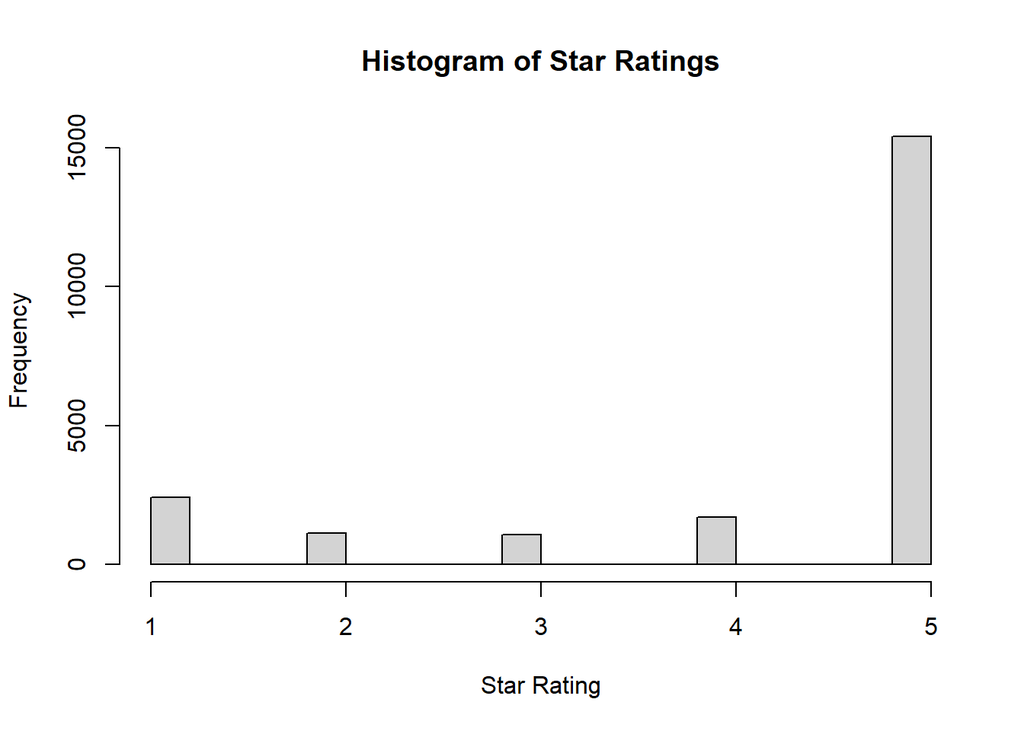

# Tests

## T-Tests

```r
sds = c(sd(reviews$stars),
        sd(reviews$stars[reviews$contains_dairy == 0]),
        sd(reviews$stars[reviews$contains_dairy == 1]))
names(sds) = c("Overall", "Contains Dairy", "Does Not Contain Dairy")
sds
```

```
##                Overall         Contains Dairy Does Not Contain Dairy
##              1.3841208              0.9977476              1.3989193
```

Because the standard deviations are different from each other, I will use the Welch T-test to determine if average ratings are different for dairy-containing ice creams from dairy-free ice creams.

$H_0: \mu_{dairy} = \mu_{dairy free}$ $\\H_A: \mu_{dairy} \neq \mu_{dairy free}$

```r
dairy_free = reviews$stars[reviews$contains_dairy == 0]
dairy = reviews$stars[reviews$contains_dairy == 1]
t.test(x = dairy,
       y = dairy_free,
       alternative = "two.sided",
       mu = 0,
       var.equal = FALSE,
       conf.level = 0.95)
```

```
##
##  Welch Two Sample t-test
##
## data:  dairy and dairy_free
## t = -13.718, df = 1388.4, p-value < 2.2e-16
## alternative hypothesis: true difference in means is not equal to 0
## 95 percent confidence interval:
##  -0.4895150 -0.3670283
## sample estimates:
## mean of x mean of y
##  4.201587  4.629859
```

## Question 9

We are interested in testing whether the mean rating between ice cream brands is equal. To accomplish this, we will use ANOVA in order to test the following null hypothesis:

$H_0: mu_{bj} == mu_{breyers} == mu_{hd} == mu_{talentyi}$ $\\H_A: \mu_{bj} \neq \mu_{breyers} \neq \mu_{hd} \neq \mu_{talenti}$

Average rating and standard deviation for every ice cream brands:

```r
with(reviews, tapply(reviews$stars, reviews$brand, mean)) # mean
```

```
##       bj  breyers       hd  talenti
## 4.305804 4.027961 4.218475 4.311624
```

```r
with(reviews, tapply(reviews$stars, reviews$brand, sd)) # std dev
```

```
##       bj  breyers       hd  talenti
## 1.315225 1.498173 1.406964 1.317089
```

```r
summary(aov(stars ~ brand, data = reviews))
```

```
##                Df Sum Sq Mean Sq F value Pr(>F)
## brand           3    277   92.32   48.51 <2e-16 ***
## Residuals   21670  41244    1.90
## ---
## Signif. codes:  0 '***' 0.001 '**' 0.01 '*' 0.05 '.' 0.1 ' ' 1
```

The F-statistic is highly significant, hence there is significant evidence to reject the null hypothesis that the average rating of ice cream flavor is the same between all brands.